# UMD’s Land Grab History

Ethan Huegler

3/2/2021

# Land Grab Universities

[Land Grab Universities](https://www.landgrabu.org/#about) is a project by *High Country News* to create a database of all of the indigenous land granted to American Universities through the Morrill Act. The Morrill Act sought out to make higher education accessible to a significantly wider range of people. It did so buy distributing land to State Universities to raise money for those schools (Alexander). What many people do not realize is that the land was not just for the campuses themselves. Western schools were allowed to claim land parcels within their state, while Eastern schools-who did not have such public land within the state where given parcels of land all over the country (Alexander).

# The University of Maryland

Being one of the 52 Morrill Act schools, the University of Maryland was given parcels of land throughout the country. The Land Grab Universities database contains information about where and when that land was given, as well as the indigenous owners from which the land was bought or taken. Without seeing it on a map it can be very difficult to understand just how wide of an area was affected by the land grants. UMD has made an effort to respect the groups whos land was used to fund the University with through the land acknowledgment statement.

#### Land Acknowledgment

> Every community owes its existence and strength to the generations before them, around the world, who contributed their hopes, dreams, and energy into making the history that led to this moment. Some were brought here against their will, some were drawn to migrate from their homes in hope of a better life, and some have lived on this land for more generations than can be counted. Truth and acknowledgment are critical in building mutual respect and connections across all barriers of heritage and difference.

The Land Grab U database can be used to construct a map showing the parcels of land which were given to UMD.The dates ranging from 1808 to 1865 show the date on which that land was aquired by the federal government, whether through purchase from native people of through secession.

```r
# Helper function for converting other data to lat/long coords
rescale <- function(x, from, to) {
    maxx <- max(x)
    minx <- min(x)
    out <- (to - from) * (x - minx)
    out <- out/(maxx - minx)
    out + from
}

# Create Map with Points
plot_univ <- function(univ = "University of Maryland", abrv = "UMD", univ_color = "#CF102D",
    lat = 38.990267, long = -76.943949) {
    univ_parcels <- filter(parcels, University == univ)
    univ_parcel_shapes <- parcel_shapes[parcel_shapes$MTRSA_LG %in% univ_parcels$MTRSA_LG,
        ]
    univ_parcel_shapes_data <- tidy(univ_parcel_shapes)
    locations <- univ_parcel_shapes_data %>% group_by(id) %>% summarise(lat = mean(lat),
        long = mean(long))

    i <- 1
    while (i <= nrow(locations)) {
        locations[i, 4] <- univ_parcel_shapes@data[which(univ_parcel_shapes@data[,
            1] == (as.integer(locations[i, 1]) + 1)), 2]
        locations[i, 5] <- univ_parcels[which(univ_parcels[, 1] == as.character(locations[i,
            4])), 15]
        locations[i, 6] <- univ_parcels[which(univ_parcels[, 1] == as.character(locations[i,
            4])), 10]
        locations[i, 7] <- univ_parcels[which(univ_parcels[, 1] == as.character(locations[i,
            4])), 4]
        i <- i + 1
    }

    colnames(locations) <- c(colnames(locations)[1:3], "MTRSA_LG", "date", "tribe",
        "acres")
    locations$date <- as.Date(locations$date, "%Y%m%d")
    locations[is.na(locations)] <- as.Date("1864-01-01")
    locations <- locations[order(locations$date), ]
    locations[, "cummulative_acres"] <- cumsum(locations$acres)

    rexp <- "([^;:]*).*"
    locations$tribe <- sub(rexp, "\\1", locations$tribe)

    acres_over_time <- locations %>% group_by(date) %>% summarise(acres = as.integer(max(cummulative_acres)))

    us_states <- map_data("state")

    map <- ggplot() + # Map of US
    geom_polygon(data = us_states, aes(x = long, y = lat, group = group), color = "black",
        fill = "lightgrey") + # UMD dot
    geom_point(aes(y = lat, x = long), fill = univ_color, color = "black", size = 5,
        shape = 23) + geom_label_repel(data = data.frame(y = lat, x = long), aes(x,
        y), label = abrv, seed = 10) + # Locations
    geom_point(data = locations, aes(x = long, y = lat, group = id, fill = factor(tribe)),
        size = 4, shape = 21, color = "black") + # Acre Line
    geom_line(data = acres_over_time, aes(x = rescale(as.integer(acres), min(us_states$long),
        max(us_states$long)), y = min(us_states$lat) - 3), color = univ_color, size = 2) +
        # Acre line point
    geom_point(data = acres_over_time, aes(x = rescale(as.integer(acres), min(us_states$long),
        max(us_states$long)), y = min(us_states$lat) - 3), size = 4, color = univ_color) +
        # Acre labels
    geom_label_repel(data = acres_over_time, aes(x = rescale(as.integer(acres), min(us_states$long),
        max(us_states$long)), y = min(us_states$lat) - 3, label = as.integer(acres),
        group = 1), max.overlaps = 20, nudge_y = 1) + # Style stuff
    theme_void() + theme(legend.position = "bottom", legend.key = element_blank(),
        legend.key.size = unit(1, "point"), legend.margin = margin(1, 1, 10, 1, "pt"),
        axis.title.x.bottom = element_text()) + guides(fill = guide_legend(override.aes = list(size = 4),
        ncol = 1, )) + labs(title = paste("  Locations of Land Aquired by the", univ),
        fill = "Tribal Land Belonged to:", x = "Total Acres Aquired by University of Maryland by {frame_along}\n\n")

    return(map)
}

# animate points to appear over time
animate_plot <- function(p, w = 750, h = w, d = 40, ep = 20) {
    animation0 <- animate(plot = p + transition_reveal(as.Date(date)) + enter_fade(),
        width = w, height = h, duration = d, end_pause = ep, renderer = gifski_renderer())
    return(animation0)
}
```

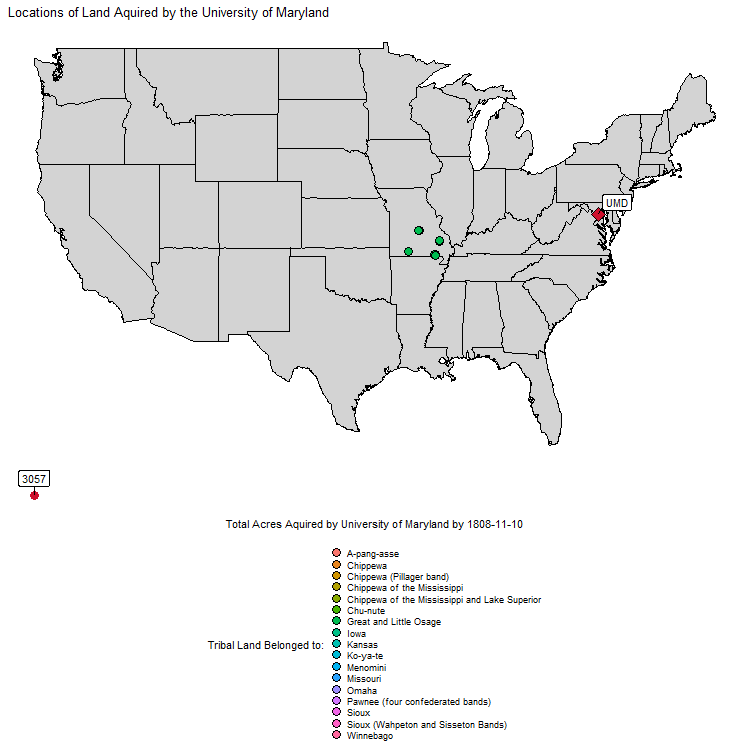

```r
# Display plot of UMD's land grab history.
animate_plot(plot_univ())
```

In total UMD was granted 202,971 acres of indiginous land, or about 315 square miles of land, land that was not even in the state of Maryland. In comparison, the College Park campus has a foot print of about 2 square miles. Adjusted for inflation, it cost the federal government $360,924 to acquire the land, and in the end it raised $1,866,138 for the University.

# Other Universities

The other land grant institutions all have similar stories. They were granted significant amounts of land from across the country. Some schools, such as Penn State, were given over double what UMD recieved, and the map reflects just how many differnt indiginous geoups were affected.

#### West Virginia University

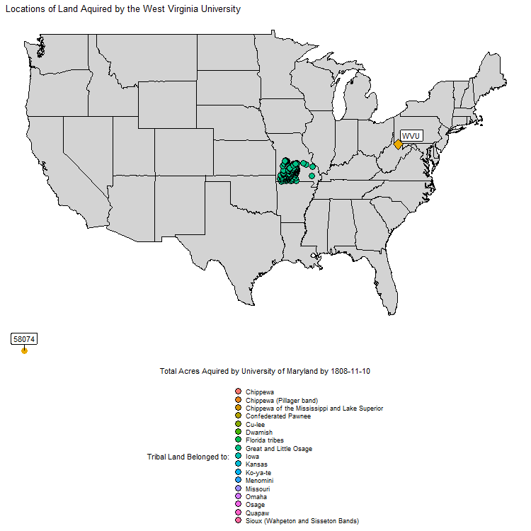

```r
animate_plot(plot_univ(univ = "West Virginia University", abrv = "WVU", univ_color = "#EAAA00", lat = 39.648788, long = -79.971902))
```

#### Rutgers

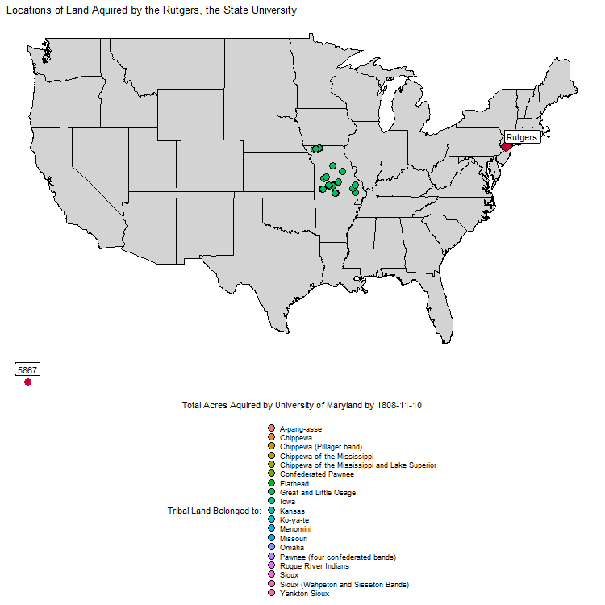

```r
animate_plot(plot_univ(univ = "Rutgers, the State University", abrv = "Rutgers", univ_color = "#cc0033", lat = 40.521647, long = -74.446857))
```

#### University of Connecticut

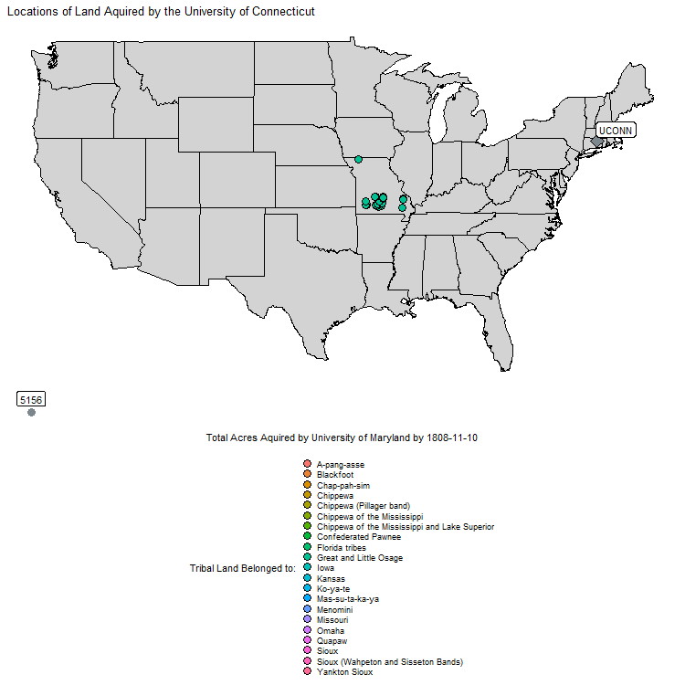

```r
animate_plot(plot_univ(univ = "University of Connecticut", abrv = "UCONN", univ_color = "#7C878E",
    lat = 41.807497, long = -72.254335))
```

#### Pennsylvania State University

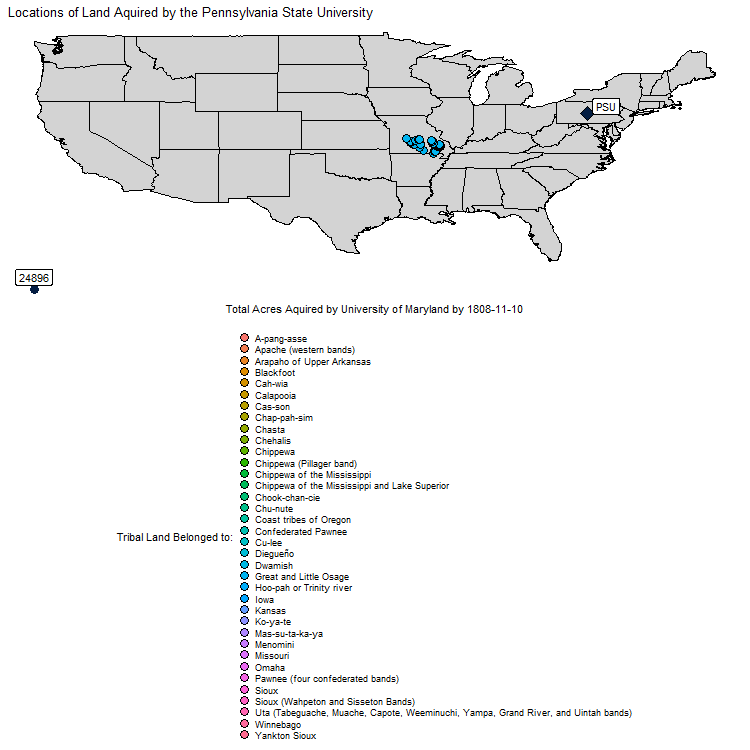

```r
animate_plot(plot_univ(univ = "Pennsylvania State University", abrv = "PSU", univ_color = "#041E42",
    lat = 40.797641, long = -77.860413))
```

# Works Cited

Alexander, Dexter L. “Land-Grant Colleges and Popular Revolt: The Origins of the Morrill Act and the Reform of Higher Education.” *Journal of American History*, vol. 106, no. 4, Mar. 2020, pp. 1060–1061.

Robert Lee, “Morrill Act of 1862 Indigenous Land Parcels Database,” *High Country News*, March 2020.

The source code for this website can be found on [github](https://github.com/ehuegler/land-grab-umd).